# Árboles de Decisión

Técnicas de Aprendizaje de Máquina

Oscar Bustos

# Introducción

## Modelos lineales asumen fronteras planas

- **Modelos lineales:** Fronteras tipo $\beta_0 + \beta_1 X_1 + \beta_2 X_2 = 0$.
- **Regresión Logística:** Estima $P(Y=1|X)$ mediante sigmoide.
- **Ventaja:** Simplicidad, rapidez y alta interpretabilidad.

**Reflexión**

💭 ¿Qué sucede cuando los datos reales **no** son linealmente separables? ¿Se les ocurre un ejemplo?

## Patrón XOR: imposible para una recta

- Una línea recta jamás podrá separar estas clases correctamente.
- Con regresión logística, el *accuracy* será del 50%.

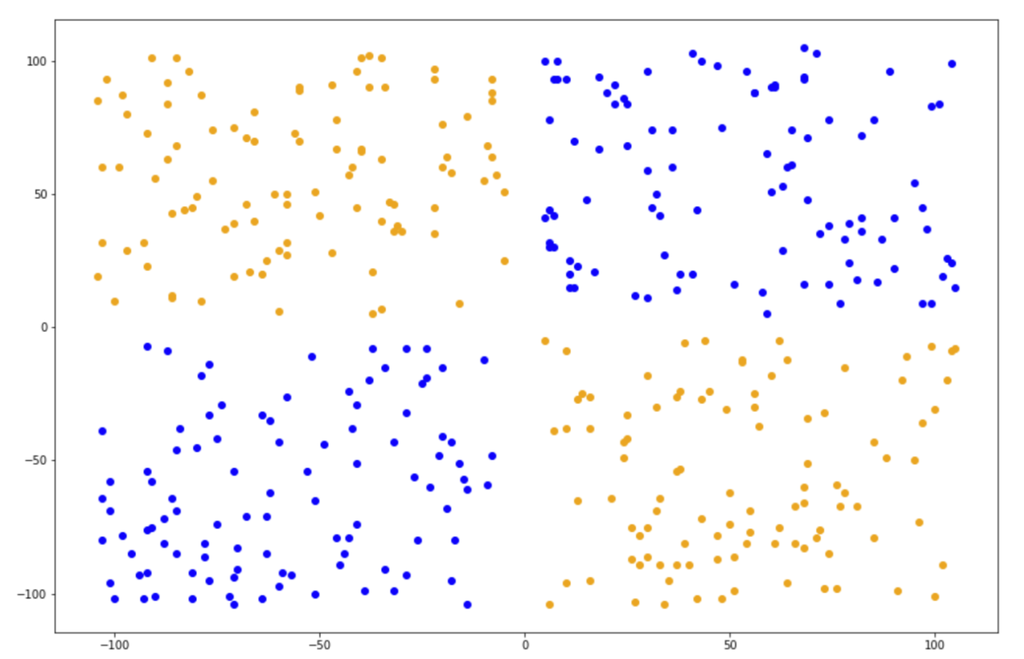

Tomado de: (Provost and Fawcett 2013)

## Redes y SVMs son difíciles de explicar

Podemos usar modelos complejos (Kernel SVM, Redes Neuronales) para separar datos no lineales de forma brillante.

**Cuestionamiento**

Pero imaginen que el modelo rechaza un crédito bancario. ¿Cómo le explicamos al cliente el rechazo basado en la matemática de un Kernel RBF?

## La no linealidad sacrifica claridad

En problemas de alto impacto (finanzas, salud), la predicción pura no basta; se exige **auditabilidad**.

- **No Linealidad:** Kernels curvan fronteras eficientemente.
- **Opacidad:** Difícil justificar el paso a paso de la decisión.
- **Caja Negra:** Reduce la confianza de los expertos del negocio.

## Sistemas BRMS usan reglas explícitas

Recordemos los sistemas **BRMS** (*Business Rules Management Systems*) como Drools o Camunda:

- Usan reglas explícitas y árboles de decisión (BPMN).
- Son 100% interpretables, deterministas y auditables.

**El Reto**

¿Cómo logramos la explicabilidad de las reglas de negocio, pero logrando que la máquina **las descubra sola** desde los datos?

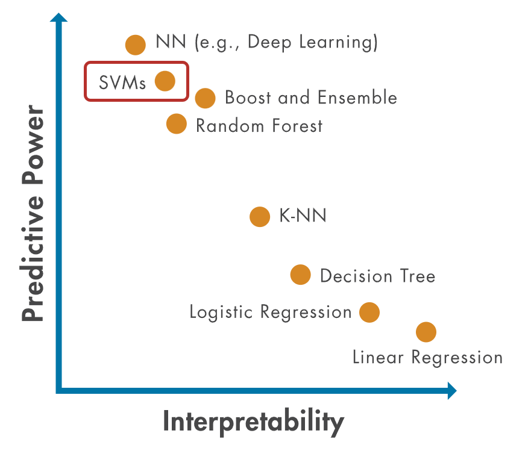

(MathWorks 2024)

## Referencia: Géron (Capítulo 6)

Capítulo 6 (Géron 2022)

## Referencias: James y Provost

Capítulo 8 (James et al. 2023)

[figure not shown]

Capítulo 3 (Provost and Fawcett 2013)

## Tarea: Lecturas

**Actividades a desarrollar:**

1. **(Obligatorio)** Leer el **Capítulo 6** de *Hands-On Machine Learning* (Géron).
2. **(Opcional)** Leer el **Capítulo 8** de *Introduction to Statistical Learning* (James et al.).
3. **(Opcional)** Leer el **Capítulo 3** de *Data Science for Business* (Provost).

## Tarea: NotebookLM

**Actividades complementarias:**

- Explorar el [Cuaderno de Google NotebookLM](https://notebook.google.com/notebook/f1e87c40-b872-466d-94ec-8544024b5986):
  - Revisar la infografía.
  - Realizar los quices incluidos.
  - Escuchar el podcast.

# Árboles y CART

## Árboles: no linealidad e interpretabilidad

**Lo mejor de ambos mundos:**

- **No lineal:** Separa patrones complejos (XOR).
- **Interpretable:** Reglas jerárquicas simples (If-Then).
- **Sin preprocesamiento:** No exige escalar variables.

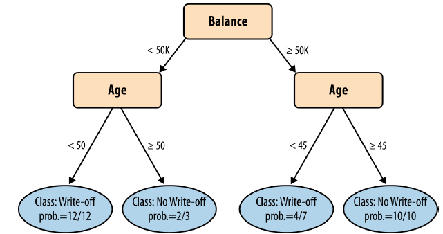

Tomado de: (Provost and Fawcett 2013)

## Algoritmo CART construye reglas

- **Algoritmo CART (*Classification and Regression Trees*):**
  - **Partición binaria recursiva:** Comienza en la raíz y divide sucesivamente los datos en dos subconjuntos cada vez más puros.
  - **Selección óptima $(k, t_k)$:** En cada nodo elige la variable y el umbral que minimizan la impureza.

**Reflexión**

¿Cómo mide matemáticamente la máquina que un “corte” o división es mejor que otro?

## Entropía y Gini miden el desorden

Se evalúa la **Ganancia de Información**. A mayor reducción del desorden, mejor es el corte.

- **Entropía=0:** Nodo puro (una sola clase).
- **Entropía=1:** Máxima mezcla (incertidumbre).

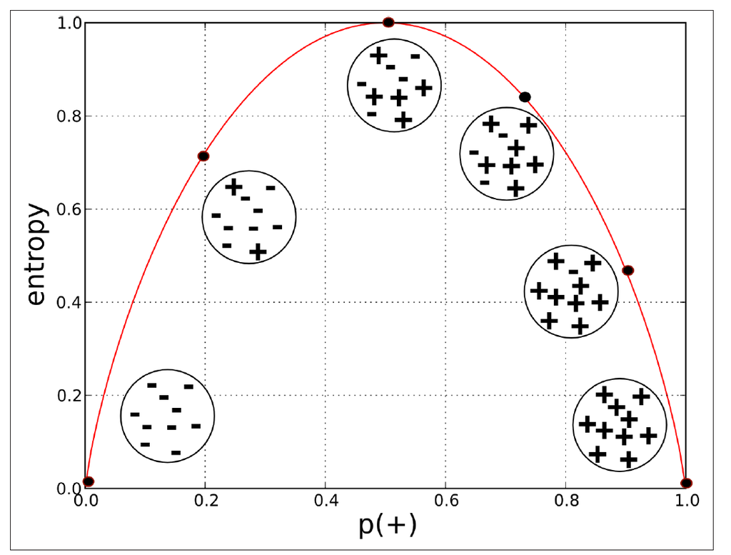

Tomado de: (Provost and Fawcett 2013)

## Escenario del Ejemplo

**Escenario:** Nodo $S$ con 10 individuos.

Imagina que estamos analizando un nodo en un árbol de decisión, al que llamamos “Nodo S”. Este nodo representa un conjunto de datos con 10 individuos.

**Clasificación:** Dentro de estos 10 individuos, tenemos dos categorías importantes:

- **3 individuos en mora** (nuestra clase positiva, por ejemplo)
- **7 individuos sin mora** (nuestra clase negativa)

## Cálculo de Probabilidades

**Cálculo de Probabilidades**

Para calcular la entropía, necesitamos las probabilidades de cada clase en el Nodo S.

- Probabilidad de “no mora”:
  $$p(\text{no-mora}) = \frac{7}{10} = 0.7$$
- Probabilidad de “mora”:
  $$p(\text{mora}) = \frac{3}{10} = 0.3$$

## Fórmula de Entropía

**Fórmula de Entropía (para dos clases)**

La fórmula general para calcular la entropía en un sistema con dos clases es:

$$\text{entropy}(S) = - p(\text{mora}) \log_2(p(\text{mora})) - p(\text{no-mora}) \log_2(p(\text{no-mora}))$$

Donde:

- $S$ representa el conjunto de datos (nuestro Nodo S)
- $p(\text{mora})$ es la probabilidad de la clase “mora”
- $p(\text{no-mora})$ es la probabilidad de la clase “no mora”

## Cálculo de Entropía (Nodo S)

**Sustituyendo valores en la fórmula**

Sustituimos las probabilidades calculadas en la fórmula de la entropía:

$$\text{entropy}(S) = - \frac{3}{10} \log_2 \left(\frac{3}{10}\right) - \frac{7}{10} \log_2 \left(\frac{7}{10}\right)$$

**Resultado Aproximado**

Calculando esta expresión, obtenemos:

$$\text{entropy}(S) \approx 0.88 \text{ bits}$$

## Ganancia de Información reduce la Entropía

La entropía ($\approx 0.88$) mide qué tan **mezcladas** están las clases (impureza). Para mejorar, usamos la **Ganancia de Información (IG)**.

- **Objetivo:** Medir la **reducción del desorden** al dividir un nodo.
- **Regla:** Mayor IG $\implies$ Mejor corte.
- El algoritmo siempre prefiere cortes que generen hijos más puros.

```
flowchart TD
    A[Padre: Mezclado] -->|Corte| B(Hijo 1: Más puro)
    A -->|Corte| C(Hijo 2: Más puro)
    B -.-> D{Ganancia de<br>Información}
    C -.-> D
```

## Ganancia de Información (Fórmula)

La fórmula para calcular la Ganancia de Información es:

$$IG(\text{padre}, \text{hijos}) = \text{entropy}(\text{padre}) - \sum_{i=1}^{n} p(hijo_i) \times \text{entropy}(hijo_i)$$

Donde:

- $IG$: Ganancia al dividir el nodo “padre”.
- $\text{entropy}(\text{padre})$: Entropía **antes** de la división.
- $n$: Número de nodos hijos creados.
- $p(hijo_i)$: Proporción de individuos que se dirigen al nodo hijo $i$.
- $\text{entropy}(hijo_i)$: Entropía **después** de la división.

## Ganancia de Información (Balance)

$IG = entropy(padre)$  
$- p(\text{Bal.} < 50K) \times entropy(\text{Bal.} < 50K)$  
$- p(\text{Bal.} \geq 50K) \times entropy(\text{Bal.} \geq 50K)$

$IG \approx 0.99 - 0.43(0.39) - 0.57(0.79)$  
$IG \approx 0.37$

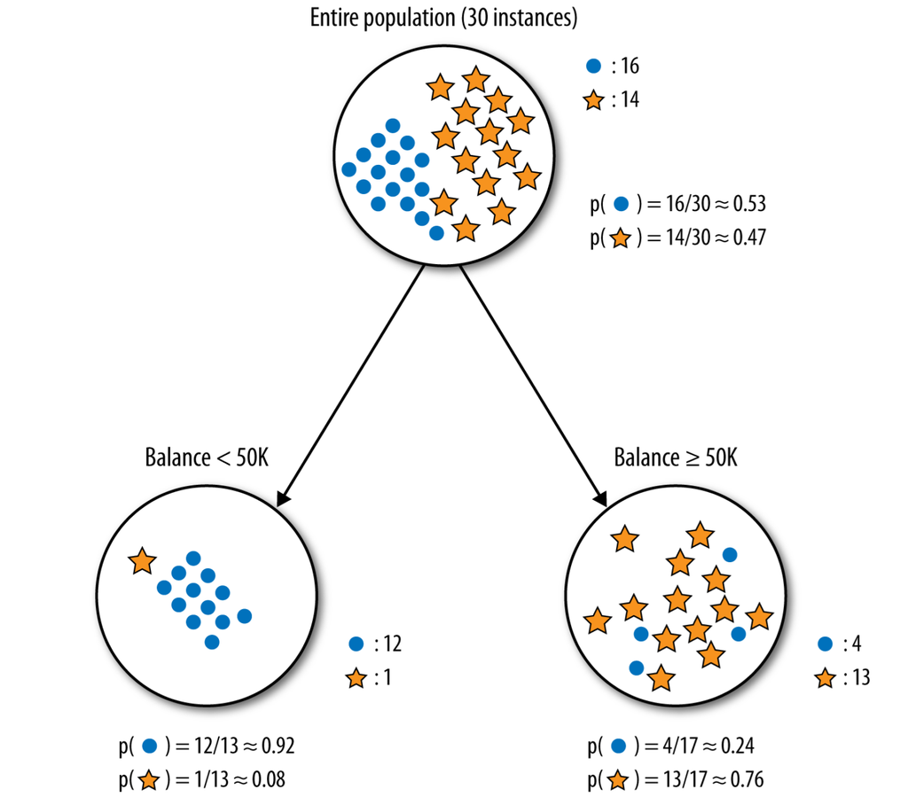

Partición usando el Balance. (Provost and Fawcett 2013)

## Ganancia de Información (Residencia)

$entropy(parent) \approx 0.99$  
$entropy(Res.=OWN) \approx 0.54$  
$entropy(Res.=RENT) \approx 0.97$  
$entropy(Res.=OTHER) \approx 0.98$  
**$IG \approx 0.13$**

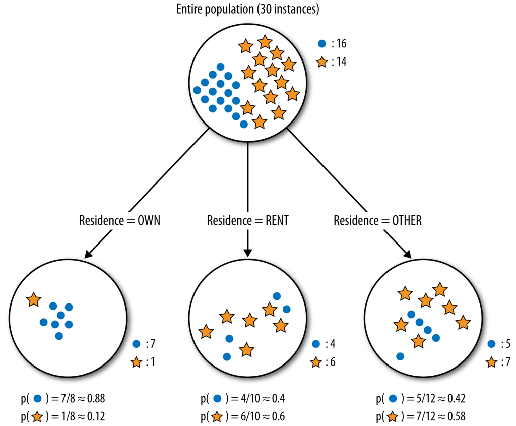

Partición usando la Residencia. (Provost and Fawcett 2013)

## Variables continuas requieren cortes óptimos

Vimos divisiones claras con clases (Residencia = OWN).

**Reflexión**

Si tenemos una variable continua como el Salario o la Edad, hay infinitos puntos. ¿Cómo decide la máquina en qué valor exacto hacer el corte (ej: Edad > 35)?

## Búsqueda exhaustiva del umbral

El algoritmo CART ordena los valores de la variable y evalúa la ganancia en todos los puntos medios posibles entre datos consecutivos.

- Se elige el umbral $t_k$ que **maximiza la pureza** (o minimiza el desorden).
- Por esto, buscar el mejor corte es computacionalmente intensivo.

## Nodos hoja estiman probabilidades

Al llegar a una hoja, el árbol predice la clase mayoritaria.

**Reflexión**

En detección de fraude, predecir “Fraude” o “No Fraude” puede ser insuficiente. ¿Cómo sabemos el grado de certeza o riesgo de esa decisión?

## Proporciones definen la probabilidad

El modelo estima probabilidades basado en la proporción de la clase en esa hoja.

- Si en el nodo final hay 49 “No-Mora” y 5 “Mora”, predecir “Mora” tiene baja certeza.
- La probabilidad estimada de *Mora* será simplemente $\frac{5}{54} \approx 9.3\%$.

## Inferencia es rápida, entrenar es lento

- **Predicción (Rápida):** Evalúa condiciones hasta llegar a una hoja $\mathcal{O}(\log_2 m)$.
- **Entrenamiento (Lento):** Busca exhaustivamente cortes continuos y categóricos.

**Pregunta sobre Convergencia**

Si el árbol sigue dividiendo para purificar… ¿Cuándo se detiene?

# Regularización

## Árboles profundos memorizan ruido

Si no lo detenemos, el árbol crece hasta que cada hoja tenga **1 sola muestra**.

```python
from sklearn.tree import DecisionTreeClassifier

tree_clf = DecisionTreeClassifier(random_state=42) # Sin límite
tree_clf.fit(X_train, y_train)

print(f"Train: {tree_clf.score(X_train, y_train)}") # 100%
print(f"Test: {tree_clf.score(X_test, y_test)}")   # 65% (Overfitting)
```

- Aprende de memoria la data de entrenamiento, fallando en nuevos datos.

## Regularización previene el sobreajuste

**Estrategia**

¿Cómo le indicamos al algoritmo que se detenga antes de aprenderse de memoria los datos (*overfitting*)?

- Ajustando **hiperparámetros de poda**:
  - `max_depth`: Limita la profundidad máxima del árbol.
  - `min_samples_leaf`: Mínimas muestras requeridas en una hoja.

## Pre-poda limita crecimiento en Python

```python
from sklearn.tree import DecisionTreeClassifier

tree_reg = DecisionTreeClassifier(
    max_depth=4, min_samples_leaf=5, random_state=42
)
tree_reg.fit(X_train, y_train)

print(f"Test Accuracy: {tree_reg.score(X_test, y_test)}") # 88%
```

- Al obligar hojas de mínimo 5 muestras, el modelo generaliza mejor.

# Árboles de Regresión

## Regresión: Predecir valores numéricos

Hasta ahora clasificamos categorías (Mora vs No-Mora).

**Reflexión**

¿Cómo adaptamos los cortes si queremos predecir el valor continuo de una casa en dólares? ¿Qué usaríamos en vez de medir Entropía o Gini?

## Árboles minimizan la Varianza

En vez de buscar “pureza de clases”, el árbol busca que los valores en la hoja sean parecidos.

- **Métrica:** Mayor reducción de Varianza (minimizar el MSE).
- **Predicción:** Es el **promedio** de los valores en el nodo hoja.

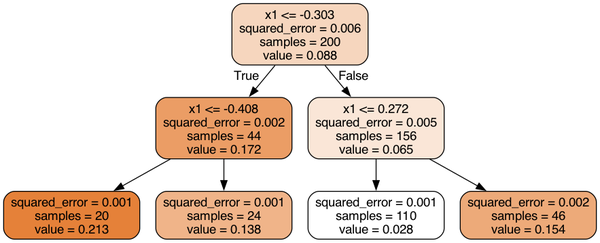

Árbol de Regresión. Tomado de: (Géron 2022)

## La predicción es escalonada

Como el modelo promedia los datos en cada región separada por cortes, la línea de predicción luce como escalones planos horizontales.

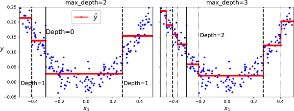

Predicciones constantes por región. Tomado de: (Géron 2022)

# Limitaciones

## Árboles generan particiones ortogonales

Observen cómo se forman las áreas de decisión de un árbol:

**El Problema Diagonal**

Las reglas siempre son paralelas a los ejes. ¿Qué sucede si la frontera óptima es una línea diagonal?

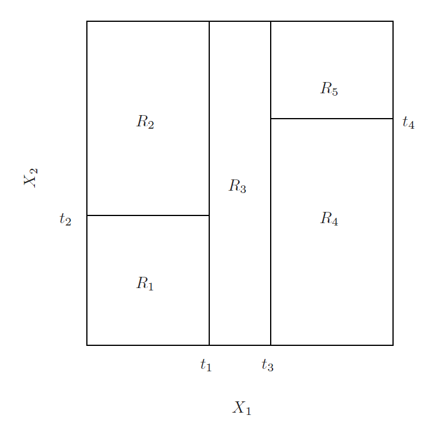

Tomado de: (Géron 2022)

## Cortes ortogonales sufren en diagonales

El árbol intenta imitar la diagonal con cientos de escalones microscópicos.

- **Consecuencia:** Requiere mucha profundidad.
- El modelo se vuelve complejo y propenso al **sobreajuste**.

[figure not shown]

Tomado de: (Géron 2022)

## PCA rota datos antes del árbol

Si rotamos el dataset usando **PCA** antes de aplicar el árbol, alineamos los datos con los ejes y simplificamos los cortes.

```python
from sklearn.pipeline import make_pipeline
from sklearn.decomposition import PCA
from sklearn.preprocessing import StandardScaler

pipeline = make_pipeline(
  StandardScaler(),
  PCA(), # Descorrelaciona y alinea variables
  DecisionTreeClassifier(max_depth=3)
)
```

## PCA alinea los datos a ejes del árbol

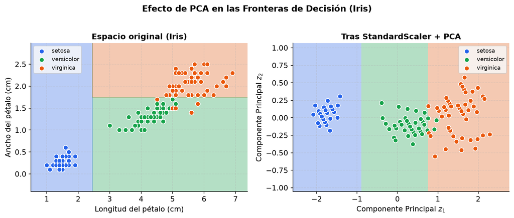

Tomado de: (Géron 2022)

## Árboles sufren de alta inestabilidad

Tenemos un modelo interpretable, capaz de modelar no linealidad y correctamente regularizado.

**Pregunta de Cierre**

¿Qué creen que pasaría con la forma matemática de este árbol si le quitamos apenas el 5% de los datos y volvemos a entrenar?

## Cambios leves generan árboles distintos

- CART es un algoritmo voraz y estocástico.
- Un cambio leve en los datos iniciales puede alterar la primera división (raíz), cambiando **todo el resto del árbol**.

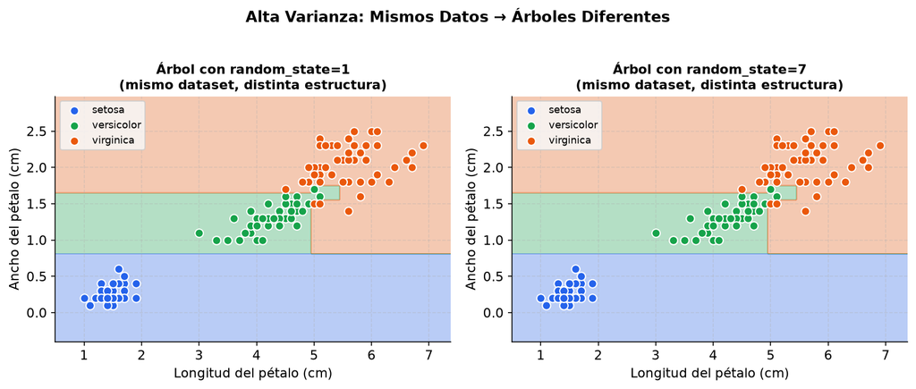

- **Solución:** Entrenar múltiples árboles y promediarlos (*Random Forest*).

## Referencias

Géron, Aurélien. 2022. *Hands-on Machine Learning with Scikit-Learn, Keras, and TensorFlow: Concepts, Tools, and Techniques to Build Intelligent Systems*. 3rd ed. O’Reilly Media, Inc.

James, Gareth, Daniela Witten, Trevor Hastie, Robert Tibshirani, and Jonathan Taylor. 2023. *An Introduction to Statistical Learning: With Applications in Python*. Springer Nature.

MathWorks. 2024. “Support Vector Machines for Machine Learning.” https://la.mathworks.com/discovery/support-vector-machine.html.

Provost, Foster, and Tom Fawcett. 2013. *Data Science for Business: What You Need to Know about Data Mining and Data-Analytic Thinking*. O’Reilly Media, Inc.